# R Intro für Biotechnologen

## 3.9 Verteilungsmodelle

R kennt eine menge verschiedener Verteilungsmodelle, hier ein Paar interessante:

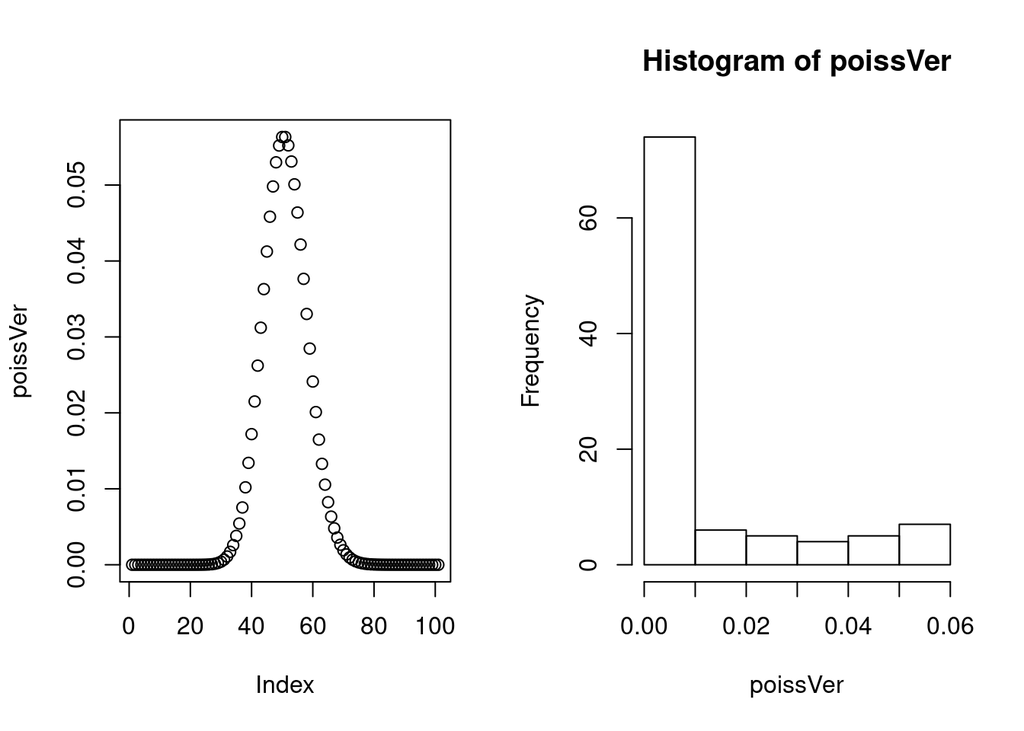

```r
# Die Poisson-Verteilung
poissVer <- dpois(x = seq(0, 100, 1), lambda = 50)

par(mfrow=c(1,2))
plot(poissVer)
hist(poissVer)
```

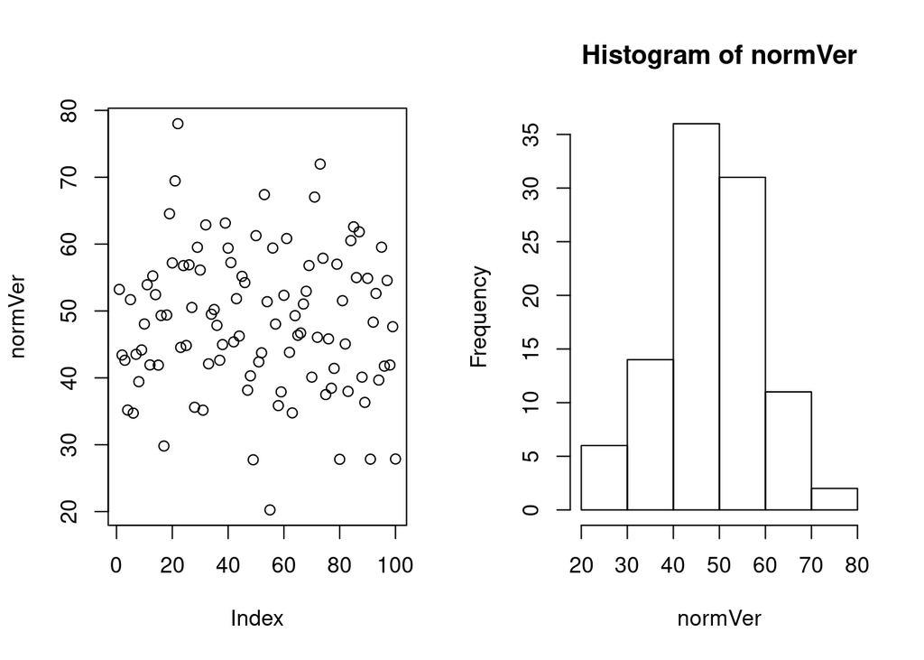

```r
# Die Normalverteilung
normVer <- rnorm(n = 100, mean = 50, sd = 10)

par(mfrow=c(1,2))
plot(normVer)
hist(normVer)
```

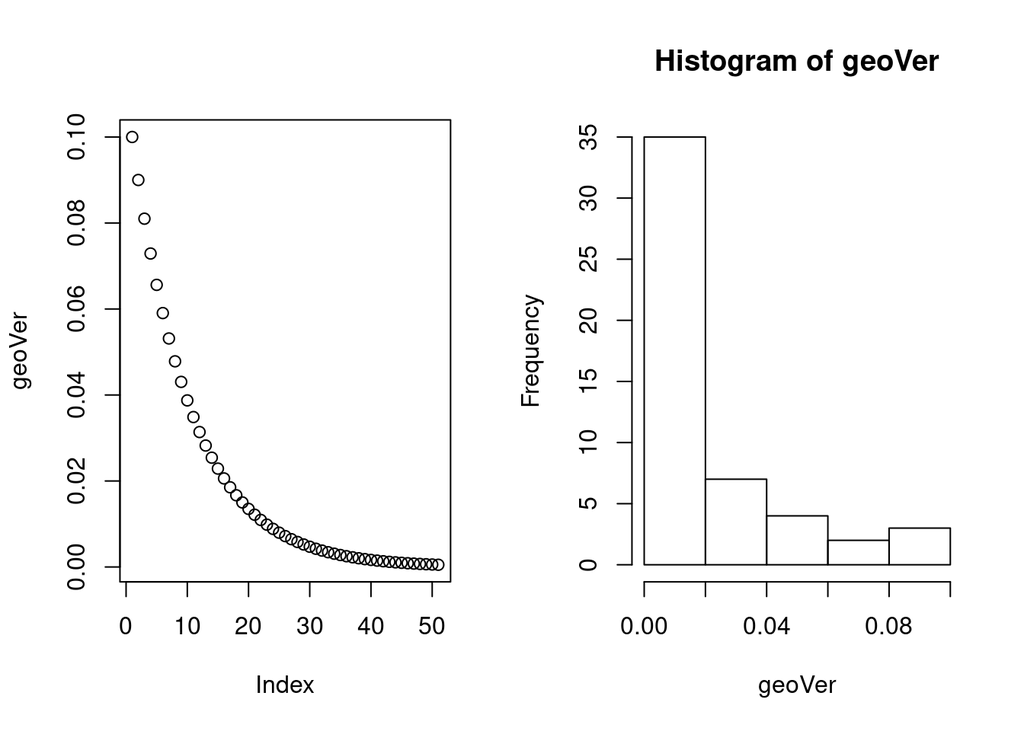

```r
# geometrische Normalverteilung
geoVer <- dgeom(x = 0:50, prob = .1)
plot(geoVer)
hist(geoVer)
```

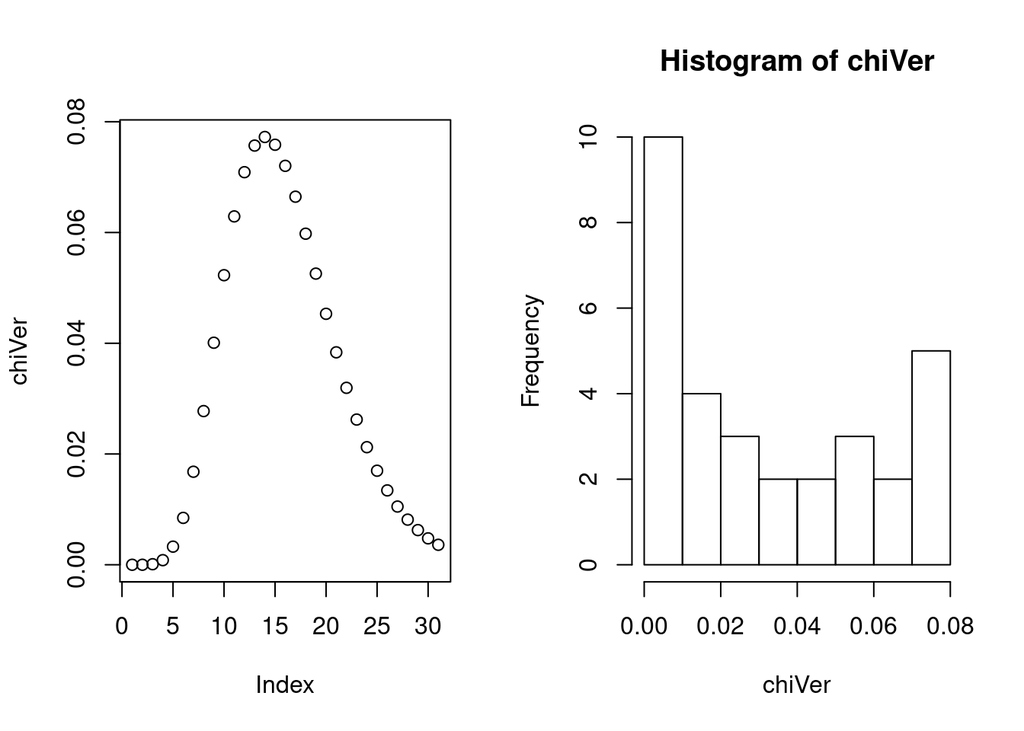

```r
# Chi-Quadrat-Verteilung
chiVer <- dchisq(x = 0:30, df = 15)
plot(chiVer)
hist(chiVer)
```

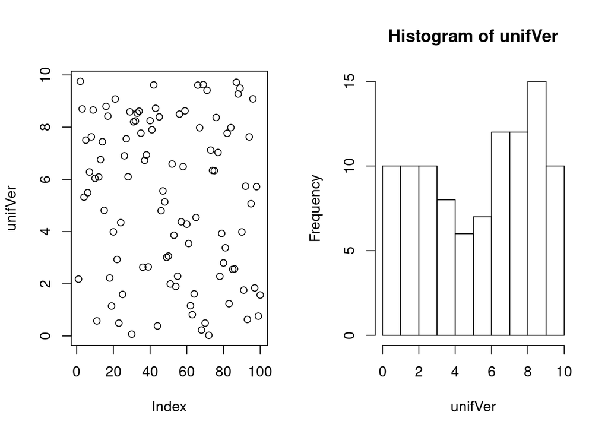

```r
# Uniform Verteilung
unifVer <- runif(n = 100, min = 0, max = 10)
plot(unifVer)
hist(unifVer)
```

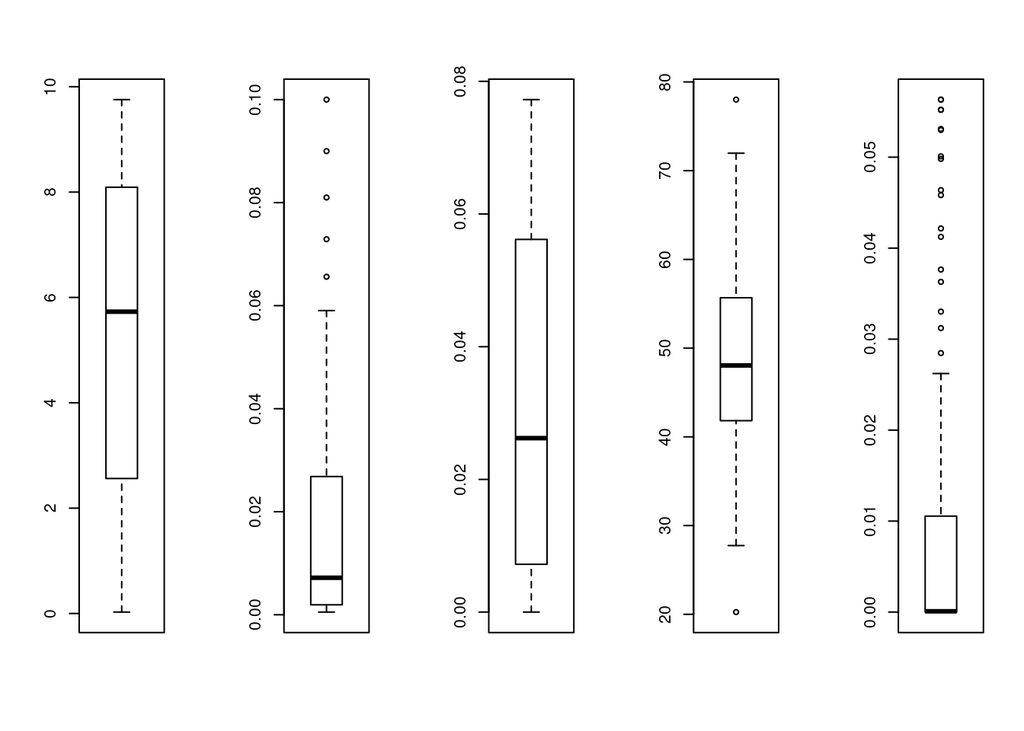

```r
par(mfrow=c(1,5))
# boxplots der Verteilungen
boxplot(unifVer)
boxplot(geoVer)
boxplot(chiVer)
boxplot(normVer)
boxplot(poissVer)
```

Diese Verteilungs-Funktionen können gut genutzt werden, um experimentelle Daten zu simulieren.

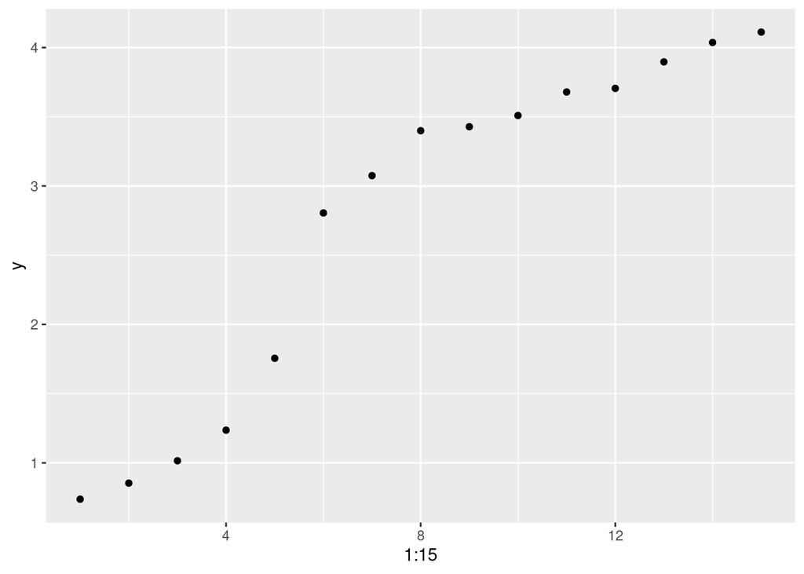

```r
m = rnorm(n = 1)
x = sort(
         runif(n = 15,
               min = 1,
               max = 13)
)
b = rnorm(n = 1)
# Werte in einen Kontext bringen:
y <- c(m * x + b)
# Plotten wir nun mit gglplot
library(ggplot2)
plot1 <- ggplot(mapping = aes( x = 1:15, y = y ))
plot2  <- plot1 + geom_point()
plot2
```

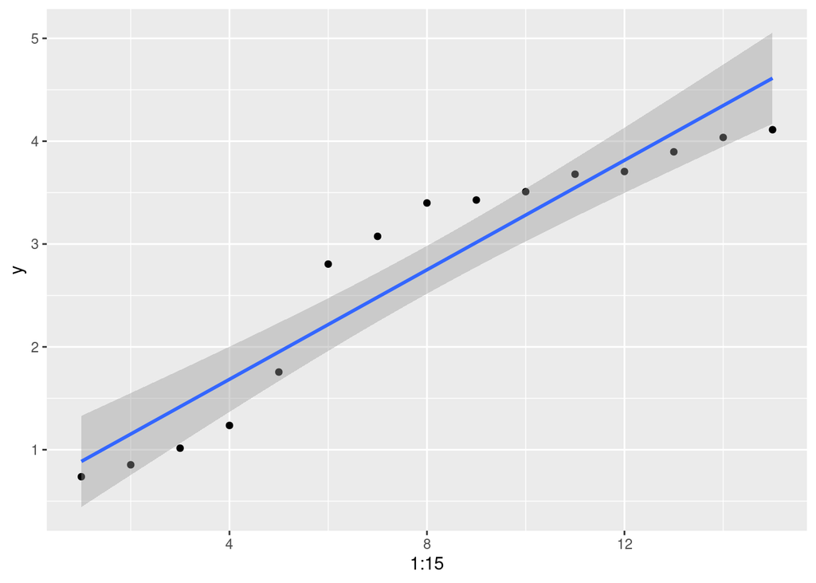

```r
# Wir können nun eine Regressionsgerade einplotten
plot2 + geom_smooth(method = "lm")
```

```r
# Und die Parameter "intercept"(=b) sowie "slope"(=m) ermitteln
x <- seq(1,15,1)

# Wir fangen nun an der magrittr-forward-pipe-operator ( %>% ) zu verwenden
library(magrittr)
modell <- lm(y~x)  %>%
   summary()

# Diese Ergebnisse können auch als Sätzchen formuliert werden:
paste("Das Modell hat die Steigung m",
      paste(modell$coefficients[2]),
      "und einen Schnittpunkt mit der y-Achse bei",
      paste(modell$coefficients[1]))
```

```
## [1] "Das Modell hat die Steigung m 0.266182084040863 und einen Schnittpunkt mit der y-Achse bei 0.620067762335794"
```

Wir simulieren nun verschiedene Aktivitätsbestimmungen von Typ-Michaelis-Menten-Enzymen:

```r
# Mit dieser Funktion möchten wir die Daten generieren
MicMen <- function (S, kM, Vmax) {
    v <- (Vmax * S) / (kM + S)
    return(v)
}

# Wir definieren Substratkonzentrationen:
S1 =  c(.1, .125, .15, .175, .2, .25, .3, .4, .5, .7, 1, 2, 5, 10, 20,
40, 60, 80, 100)
# Ein fiktives Vmax
vMax1 = 3
# Und ein fiktives kM
kM1 = .1

MM1 <- MicMen( S = S1, Vmax = vMax1, kM = kM1 )

# Wir werden nun das Modell fitten, dies wird über das Paket drc gehen
# install.packages("drc")
library(drc)

Daten <- data.frame( S = S1, v = MM1 )

fit1 <- drm(
            v~S,
            data = Daten,
            # Hier spezifizieren wir das Modell, ein 2-Parameter MM-Modell
            fct = MM.2()
)

# Wie ist unser Modell nun?:
summary(fit1)
```

```
##
## Model fitted: Michaelis-Menten (2 parms)
##
## Parameter estimates:
##
##                 Estimate Std. Error t-value   p-value
## d:(Intercept) 3.0000e+00 1.9603e-06 1530373 < 2.2e-16 ***
## e:(Intercept) 1.0000e-01 3.6866e-07  271257 < 2.2e-16 ***
## ---
## Signif. codes:  0 '***' 0.001 '**' 0.01 '*' 0.05 '.' 0.1 ' ' 1
##
## Residual standard error:
##
##  5.689949e-06 (17 degrees of freedom)
```

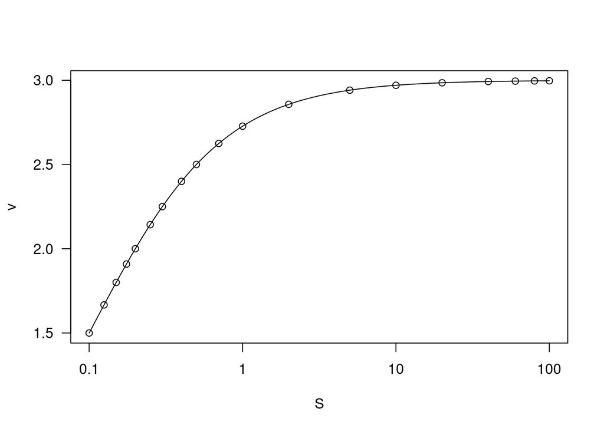

```r
par(mfrow = c(1,1))
plot(fit1)
```

# 4 Auswertung einer 96-Well-Platte

Das Paket Biotech enthält Datensätze welche zum Testen und Experimentieren angefügt wurden, zwei davon sind ELISA-Assays wie sie im Immunologischen Praktikum zum Nachweis vom Humanserumalbumin in Urin entstehen. Um uns zu verdeutlichen wie groß die Absorptionen in welchen Wells waren können wir durch das anfertigen einer Heatmap schnell die gemessenen Daten visualisiert vor Augen führen. Eine Heatmap ordnet einem Wert eine Farbintensität zu, hierbei kann die räumliche Anordnung leicht berücksichtigt werden.

```r
str(HSA1)
```

```
## tibble [8 x 14] (S3: tbl_df/tbl/data.frame)
##  $ clara: chr [1:8] "A" "B" "C" "D" ...
##  $ s1   : num [1:8] -42.1 -42 -42 -42 -41.7 ...
##  $ s2   : num [1:8] -4 -1.46 12.95 18.74 28.12 ...
##  $ s3   : num [1:8] -5.088 0.187 10.266 19.309 29.059 ...
##  $ s4   : num [1:8] -7.02 2.07 10.08 17.14 29.86 ...
##  $ s5   : num [1:8] 4.85 -8.15 -8.2 19.12 8.71 ...
##  $ s6   : num [1:8] 4.43 -4.85 13.89 19.07 4.71 ...
##  $ s7   : num [1:8] -6.5 17.61 1.65 21.66 -8.34 ...
##  $ s8   : num [1:8] -5.983 13.987 0.234 18.603 -10.787 ...
##  $ s9   : num [1:8] -6.69 3.3 -10.65 -8.71 -9.47 ...
##  $ s10  : num [1:8] -9.23 4.76 -6.93 -10.88 -4.15 ...
##  $ s11  : num [1:8] 13.94 19.45 -21.71 -4.76 -2.12 ...
##  $ s12  : num [1:8] 17.1426 15.3057 -19.5948 -3.6282 0.0455 ...
##  $ Std  : num [1:8] -5.371 0.265 11.098 18.399 29.012 ...
```

## 4.1 Rohdatenaufarbeitung und Plotten

Um nur die Informationen zu bekommen, die wir benötigen werden wir ein paar Transformationsschritte durchführen:

```r
daten <- HSA1[,2:13] %>%
    as.matrix() %>%
    as.vector()
```

Nun liegen die Messwerte als Vektor in lineare Form vor, diese können wir in einem Grid “fangen”, dazu müssen wir dieses Grid erst mal “aufspannen”:

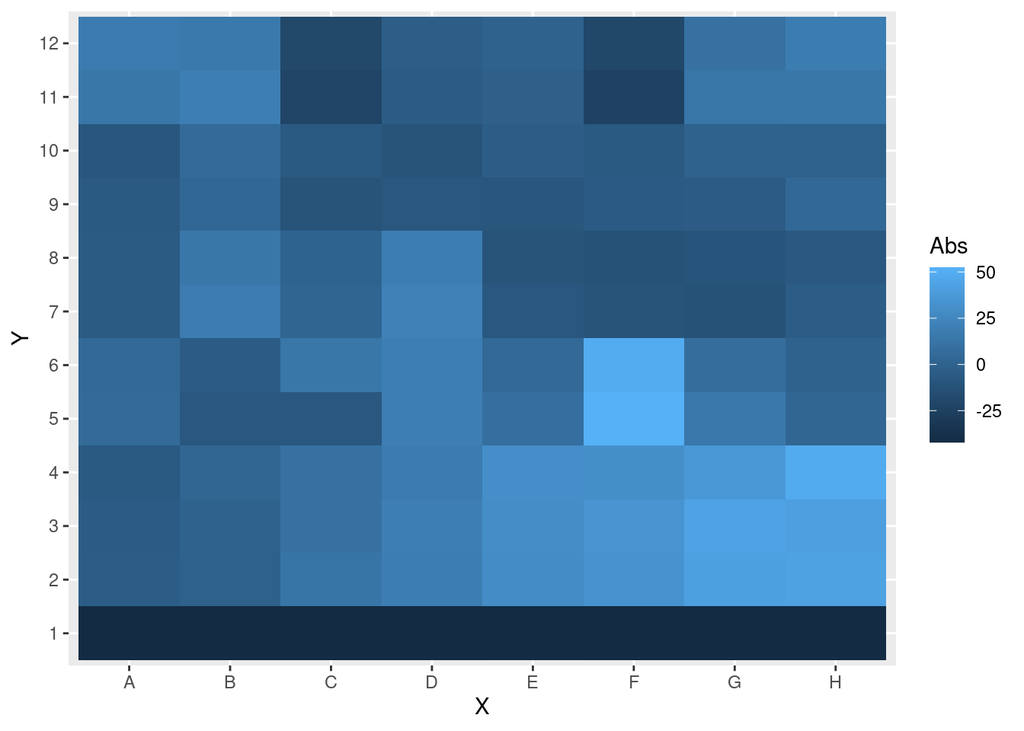

```r
# y wird durchnummeriert, als charcter
y  <- paste0(seq(1,12))

# x bekommt die erstest acht Buchstaben des Alphabets
x <- LETTERS[1:8]

# erstellen des Grid
grid.1 <- expand.grid(X = x, Y = y)

# füllen des Grid mit den Daten als Abs
grid.1$Abs <- daten

# plotten des Grid
ggplot( data = grid.1, mapping = aes( X, Y, fill = Abs ) )+
    geom_tile()
```

## 4.2 Definition einer Funktion

Um in Zukunft schneller das selbe machen zu können schreiben wir eine Funktion welche diese Aufgabe übernimmt. R ist eine funktionale Programmsprache, das bedeutet, dass es für viele Probleme bereits Funktionen gibt. Dies erleichtert gerade nicht-Programmierern das schreiben von Skripten. Sollte nun jedoch, wie in unserem Fall, keine Funktion für das Problem zur Hand sein wird diese einfach geschrieben:

```r
    # Name:
vis96 <-
    # die function-Funktion
    function(
             # Die Argumente der Funktion vis96
             HSA.assay) {
    # die eigentliche Funktion
    daten <- HSA.assay[,2:13] %>%
    as.matrix() %>%
    as.vector()
    y  <- paste0(seq(1,12))
    # x bekommt die erstest acht Buchstaben des Alphabets
    x <- LETTERS[1:8]
    # erstellen des Grid
    grid.1 <- expand.grid(X = x, Y = y)
    # füllen des Grid mit den Daten als Abs
    grid.1$Abs <- daten
    # plotten des Grid
    vis96 <- ggplot( data = grid.1, mapping = aes( X, Y, fill = Abs ) )+
        geom_tile()
    # Definition der Ausgabe
    return(vis96)
}
```

Wir können diese Funktion nun testen, dazu verwenden wir den zweiten HSA-Assay (HSA2):

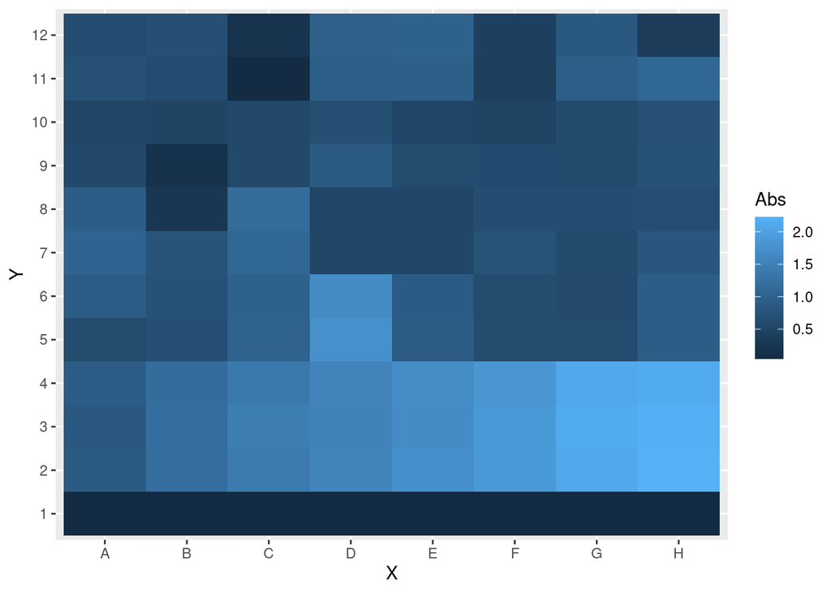

```r
vis96(HSA.assay = HSA2)
```

Die Vorteil des Verwendens einer Funktion werden im Beispiel klar:

- die Funktion bedeutet weniger Tippen
- sie macht den Code übersichtlicher

Ein weiterer Vorteil ist, dass die Funktion leicht geändert werden kann, wenn nun zum Beispiel eine Änderung in der Methode (Format der Ausgabe) des Assays eingeführt wird kann die Funktion einfach geändert werden.

## 4.3 Vergleich mit den zu erwartenden Werten

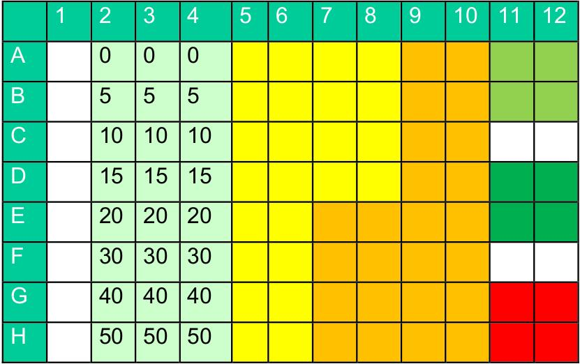

So wird klar, dass beim ersten Test (HSA1) dieses Schema richtig angewandt wurde, abhängig von der Konzentration variiert auch der die Intensität der jeweils gemessenen Zelle. Besonders klar deutlich wird das anhand der Standardreihen sowie den Patientenproben. Ins Auge fallen die Werte F5 und F6. Für den 2. Assay können wir einen ähnlichen Zusammenhang feststellen, auch auf diesem ist vor allem die Standardreihe sichtbar.

# 5 Konzentrationsbestimmung für den HSA-Assay

## 5.1 Rohdatenverarbeitung

Vor Beginn der Berechnung der HSA-Konzentration in den Proben müssen wir den Mittelwert der Standardreihen berechnen, die Herausforderung besteht hierbei darin die passenden Spalten zu selektieren. Anhand des Pipettierschemas kann nachvollzogen werden, dass die entsprechenden Auftragungen in den Spalten 2 bis 4 liegen.

```r
# wo liegen die Werte der Standards
stdr <- HSA1[3:5]  %>%
    rowMeans()
```

Aus dieser Standardreihe können wir dann wieder, wie bereits vorher geschehen, eine Regression errechnen:

```r
# Zuordnung der Konzentrationen
conc <- c(0, 5, 10, 15, 20, 30, 40, 50)

# welche Konzentrationen gibt das Modell für die Standards aus
conc_eval(abs_P = stdr, abs_std = stdr, conc_std = conc)
```

```
##
## Call:
## stats::lm(formula = conc_std ~ abs_std)
##
## Residuals:
##     Min      1Q  Median      3Q     Max
## -8.3909 -2.3392 -0.0641  3.1028  7.7572
##
## Coefficients:
##             Estimate Std. Error t value Pr(>|t|)
## (Intercept)   1.6994     3.0164   0.563 0.593584
## abs_std       0.9200     0.1107   8.308 0.000165 ***
## ---
## Signif. codes:  0 '***' 0.001 '**' 0.01 '*' 0.05 '.' 0.1 ' ' 1
##
## Residual standard error: 5.338 on 6 degrees of freedom
## Multiple R-squared:   0.92,  Adjusted R-squared:  0.9067
## F-statistic: 69.03 on 1 and 6 DF,  p-value: 0.0001649
```

```
## [1] -3.241947  1.943520 11.910019 18.626572 28.390852 31.424134
## [7] 38.704011 42.242840
```

```r
# Definition einer Funktion
HSA.conc.eval <- function(HSA,
         mes) {
  stdr <- HSA[3:5]  %>%
    rowMeans()
  conc <- c(0, 5, 10, 15, 20, 30, 40, 50)
  eval <- conc_eval(abs_P = mes,
            abs_std = stdr,
            conc_std = conc)
  return(eval)
}

# Testen der Funktion
HSA.conc.eval(HSA1, HSA1[3:5])
```

```
##
## Call:
## stats::lm(formula = conc_std ~ abs_std)
##
## Residuals:
##     Min      1Q  Median      3Q     Max
## -8.3909 -2.3392 -0.0641  3.1028  7.7572
##
## Coefficients:
##             Estimate Std. Error t value Pr(>|t|)
## (Intercept)   1.6994     3.0164   0.563 0.593584
## abs_std       0.9200     0.1107   8.308 0.000165 ***
## ---
## Signif. codes:  0 '***' 0.001 '**' 0.01 '*' 0.05 '.' 0.1 ' ' 1
##
## Residual standard error: 5.338 on 6 degrees of freedom
## Multiple R-squared:   0.92,  Adjusted R-squared:  0.9067
## F-statistic: 69.03 on 1 and 6 DF,  p-value: 0.0001649
```

```
##           s2        s3        s4
## 1 -1.9853020 -2.981952 -4.758589
## 2  0.3546584  1.871299  3.604604
## 3 13.6144345 11.144476 10.971146
## 4 18.9443445 19.464336 17.471036
## 5 27.5675322 28.434184 29.170838
## 6 32.1607880 32.724112 29.387501
## 7 39.7006606 41.173969 35.237403
## 8 40.8273083 39.354000 46.547212
```

Wenn wir uns dieses Ergebnis ansehe, fällt auf, dass die Leerwerte negativ sind, das kann aber (real) nicht sein.

## 5.2 Vergleichen der Ergebnisse

Um die Ergebnisse zu vergleichen wurde das folgende Skript geschrieben:

```r
# Es werden die Ergebnisse zweier unabhängig von einander durchgeführten
# nicht-kompetitven ELISAs errechnet und verglichen

#### ELISA 1 ################################################

# Der HSA1 aus Biotech wird geladen und umbenannt
HSA <- HSA1

# Ausgeben eines Summary:
summary(HSA)
```

```
##     clara                 s1               s2
##  Length:8           Min.   :-42.11   Min.   :-4.005
##  Class :character   1st Qu.:-42.01   1st Qu.: 9.348
##  Mode  :character   Median :-41.99   Median :23.430
##                     Mean   :-41.96   Mean   :21.411
##                     3rd Qu.:-41.94   3rd Qu.:35.158
##                     Max.   :-41.68   Max.   :42.529
##        s3               s4               s5
##  Min.   :-5.088   Min.   :-7.019   Min.   :-8.1968
##  1st Qu.: 7.746   1st Qu.: 8.076   1st Qu.:-0.1311
##  Median :24.184   Median :23.501   Median : 6.7807
##  Mean   :21.411   Mean   :20.928   Mean   :10.7665
##  3rd Qu.:35.523   3rd Qu.:31.684   3rd Qu.:15.9062
##  Max.   :42.906   Max.   :48.746   Max.   :52.4199
##        s6               s7                 s8
##  Min.   :-4.853   Min.   :-12.2474   Min.   :-12.436
##  1st Qu.: 3.354   1st Qu.: -8.9857   1st Qu.:-10.834
##  Median : 6.168   Median : -5.4415   Median : -6.878
##  Mean   :11.750   Mean   : -0.1841   Mean   : -1.891
##  3rd Qu.:15.188   3rd Qu.:  5.6386   3rd Qu.:  3.672
##  Max.   :48.982   Max.   : 21.6641   Max.   : 18.603
##        s9               s10               s11
##  Min.   :-10.646   Min.   :-10.881   Min.   :-24.258
##  1st Qu.: -8.903   1st Qu.: -7.502   1st Qu.: -8.998
##  Median : -6.124   Median : -5.489   Median :  5.603
##  Mean   : -4.888   Mean   : -4.405   Mean   :  1.005
##  3rd Qu.: -2.922   3rd Qu.: -1.250   3rd Qu.: 13.999
##  Max.   :  3.672   Max.   :  4.755   Max.   : 19.450
##       s12               Std
##  Min.   :-20.396   Min.   :-5.371
##  1st Qu.: -7.620   1st Qu.: 8.390
##  Median :  4.873   Median :23.705
##  Mean   :  2.106   Mean   :21.250
##  3rd Qu.: 15.765   3rd Qu.:34.287
##  Max.   : 18.273   Max.   :44.068
```

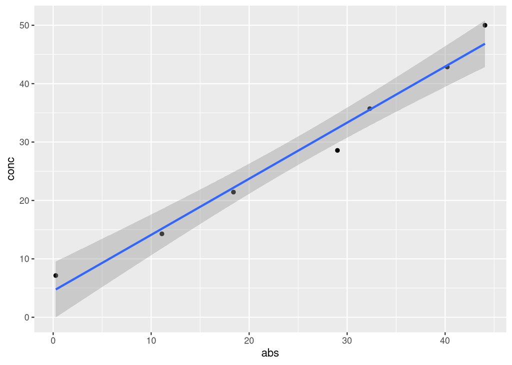

```r
library(tidyverse)

# Errechnen der Mittelwerte für die Standardreihe
HSA <- mutate(HSA, "Std"=((HSA$s2 + HSA$s3 + HSA$s4) / 3))
HSA.2 <- mutate(HSA, "Std"=((HSA$s2 + HSA$s3 + HSA$s4) / 3))

# Die Spalten 5&6, 7&8 sowie 9&10 führen neben einander die
# Probenabsorption
Proben.1 <- c((HSA$s5 + HSA$s6)/2 , (HSA$s7[1:4]+HSA$s8[1:4])/2)
Proben.2 <- c((HSA$s9 + HSA$s10)/2 , (HSA$s7[5:8]+HSA$s8[5:8])/2)



# Es ist bekannt, dass Proben.1 1:5000 verdünnt wurde:
Proben.1 <- Proben.1 * 5000

# Proben.2 wurde 1:1000 Verdünnt
Proben.2 <- Proben.2 * 1000

# Substratkonzentration
subs <- seq(0, 50, length.out = length(HSA$Std))

# Plot der Regression
plot_regression(abs = HSA$Std[2:8], conc = subs[2:8])
```

```r
# Definition einer einfachen Funktion
cHSA <- function (abs.P) {
    conc_eval( abs.P, abs_std = HSA$Std, conc_std = subs)
}

# Testen der Funktion
conc.1.1 <- conc_eval( abs_P = Proben.1, abs_std = HSA$Std , conc_std = subs )
```

```
##
## Call:
## stats::lm(formula = conc_std ~ abs_std)
##
## Residuals:
##     Min      1Q  Median      3Q     Max
## -3.8271 -0.8993 -0.0267  0.8181  3.2498
##
## Coefficients:
##             Estimate Std. Error t value Pr(>|t|)
## (Intercept)  4.74406    1.30180   3.644   0.0108 *
## abs_std      0.95322    0.04779  19.945 1.03e-06 ***
## ---
## Signif. codes:  0 '***' 0.001 '**' 0.01 '*' 0.05 '.' 0.1 ' ' 1
##
## Residual standard error: 2.304 on 6 degrees of freedom
## Multiple R-squared:  0.9851, Adjusted R-squared:  0.9827
## F-statistic: 397.8 on 1 and 6 DF,  p-value: 1.031e-06
```

```r
conc.1 <- cHSA(abs.P = Proben.1)
```

```
##
## Call:
## stats::lm(formula = conc_std ~ abs_std)
##
## Residuals:
##     Min      1Q  Median      3Q     Max
## -3.8271 -0.8993 -0.0267  0.8181  3.2498
##
## Coefficients:
##             Estimate Std. Error t value Pr(>|t|)
## (Intercept)  4.74406    1.30180   3.644   0.0108 *
## abs_std      0.95322    0.04779  19.945 1.03e-06 ***
## ---
## Signif. codes:  0 '***' 0.001 '**' 0.01 '*' 0.05 '.' 0.1 ' ' 1
##
## Residual standard error: 2.304 on 6 degrees of freedom
## Multiple R-squared:  0.9851, Adjusted R-squared:  0.9827
## F-statistic: 397.8 on 1 and 6 DF,  p-value: 1.031e-06
```

```r
# Sind die Ergebnisse die selben?
conc.1 == conc.1.1
```

```
##  [1] TRUE TRUE TRUE TRUE TRUE TRUE TRUE TRUE TRUE TRUE TRUE TRUE
```

```r
# Berechnung der Konzentrationen
conc.2 <- cHSA(Proben.2)
```

```
##
## Call:
## stats::lm(formula = conc_std ~ abs_std)
##
## Residuals:
##     Min      1Q  Median      3Q     Max
## -3.8271 -0.8993 -0.0267  0.8181  3.2498
##
## Coefficients:
##             Estimate Std. Error t value Pr(>|t|)
## (Intercept)  4.74406    1.30180   3.644   0.0108 *
## abs_std      0.95322    0.04779  19.945 1.03e-06 ***
## ---
## Signif. codes:  0 '***' 0.001 '**' 0.01 '*' 0.05 '.' 0.1 ' ' 1
##
## Residual standard error: 2.304 on 6 degrees of freedom
## Multiple R-squared:  0.9851, Adjusted R-squared:  0.9827
## F-statistic: 397.8 on 1 and 6 DF,  p-value: 1.031e-06
```

```r
# Untersuchung der Patienten-Proben
Patient.1 <- (sum(HSA[1:2, 11], HSA[1:2, 12]) / 4) * 20000
Patient.2 <- (sum(HSA[4:5, 11], HSA[4:5, 12]) /4) * 100000

# Berechnung der Patienten-Proben-Konzentration
cHSA(Patient.1)
```

```
##
## Call:
## stats::lm(formula = conc_std ~ abs_std)
##
## Residuals:
##     Min      1Q  Median      3Q     Max
## -3.8271 -0.8993 -0.0267  0.8181  3.2498
##
## Coefficients:
##             Estimate Std. Error t value Pr(>|t|)
## (Intercept)  4.74406    1.30180   3.644   0.0108 *
## abs_std      0.95322    0.04779  19.945 1.03e-06 ***
## ---
## Signif. codes:  0 '***' 0.001 '**' 0.01 '*' 0.05 '.' 0.1 ' ' 1
##
## Residual standard error: 2.304 on 6 degrees of freedom
## Multiple R-squared:  0.9851, Adjusted R-squared:  0.9827
## F-statistic: 397.8 on 1 and 6 DF,  p-value: 1.031e-06
```

```
##  abs_std
## 137805.6
```

```r
cHSA(Patient.2)
```

```
##
## Call:
## stats::lm(formula = conc_std ~ abs_std)
##
## Residuals:
##     Min      1Q  Median      3Q     Max
## -3.8271 -0.8993 -0.0267  0.8181  3.2498
##
## Coefficients:
##             Estimate Std. Error t value Pr(>|t|)
## (Intercept)  4.74406    1.30180   3.644   0.0108 *
## abs_std      0.95322    0.04779  19.945 1.03e-06 ***
## ---
## Signif. codes:  0 '***' 0.001 '**' 0.01 '*' 0.05 '.' 0.1 ' ' 1
##
## Residual standard error: 2.304 on 6 degrees of freedom
## Multiple R-squared:  0.9851, Adjusted R-squared:  0.9827
## F-statistic: 397.8 on 1 and 6 DF,  p-value: 1.031e-06
```

```
##   abs_std
## -522059.5
```

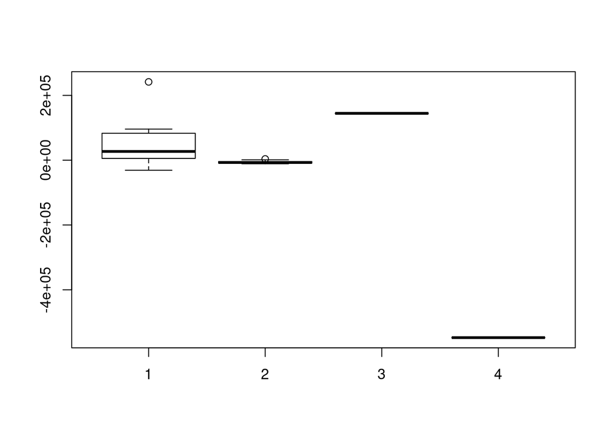

```r
# Untersuchung der Verteilung der Messwerte
boxplot(conc.1, conc.2, Patient.1, Patient.2)
```

```r
##### HSA2 ###############################################

HSA.A <- HSA2
summary(HSA.A)
```

```
##      ...1                 s1                s2
##  Length:8           Min.   :0.04400   Min.   :0.871
##  Class :character   1st Qu.:0.04500   1st Qu.:1.356
##  Mode  :character   Median :0.04600   Median :1.633
##                     Mean   :0.04625   Mean   :1.615
##                     3rd Qu.:0.04625   3rd Qu.:1.921
##                     Max.   :0.05100   Max.   :2.227
##        s3              s4              s5               s6
##  Min.   :0.843   Min.   :0.904   Min.   :0.6270   Min.   :0.6000
##  1st Qu.:1.395   1st Qu.:1.329   1st Qu.:0.6338   1st Qu.:0.7035
##  Median :1.605   Median :1.621   Median :0.7945   Median :0.8950
##  Mean   :1.615   Mean   :1.596   Mean   :0.8915   Mean   :0.9161
##  3rd Qu.:1.936   3rd Qu.:1.893   3rd Qu.:0.9370   3rd Qu.:0.9367
##  Max.   :2.194   Max.   :2.142   Max.   :1.7310   Max.   :1.6740
##        s7               s8               s9
##  Min.   :0.5330   Min.   :0.2450   Min.   :0.1710
##  1st Qu.:0.5780   1st Qu.:0.5290   1st Qu.:0.5680
##  Median :0.7610   Median :0.6555   Median :0.6190
##  Mean   :0.7624   Mean   :0.6690   Mean   :0.5956
##  3rd Qu.:0.8575   3rd Qu.:0.7265   3rd Qu.:0.6550
##  Max.   :1.0780   Max.   :1.1600   Max.   :0.8580
##       s10              s11              s12
##  Min.   :0.4770   Min.   :0.0550   Min.   :0.2010
##  1st Qu.:0.5028   1st Qu.:0.5747   1st Qu.:0.4113
##  Median :0.5390   Median :0.8155   Median :0.6620
##  Mean   :0.5696   Mean   :0.7114   Mean   :0.6406
##  3rd Qu.:0.6350   3rd Qu.:0.9400   3rd Qu.:0.8790
##  Max.   :0.7070   Max.   :1.0860   Max.   :0.9950
```

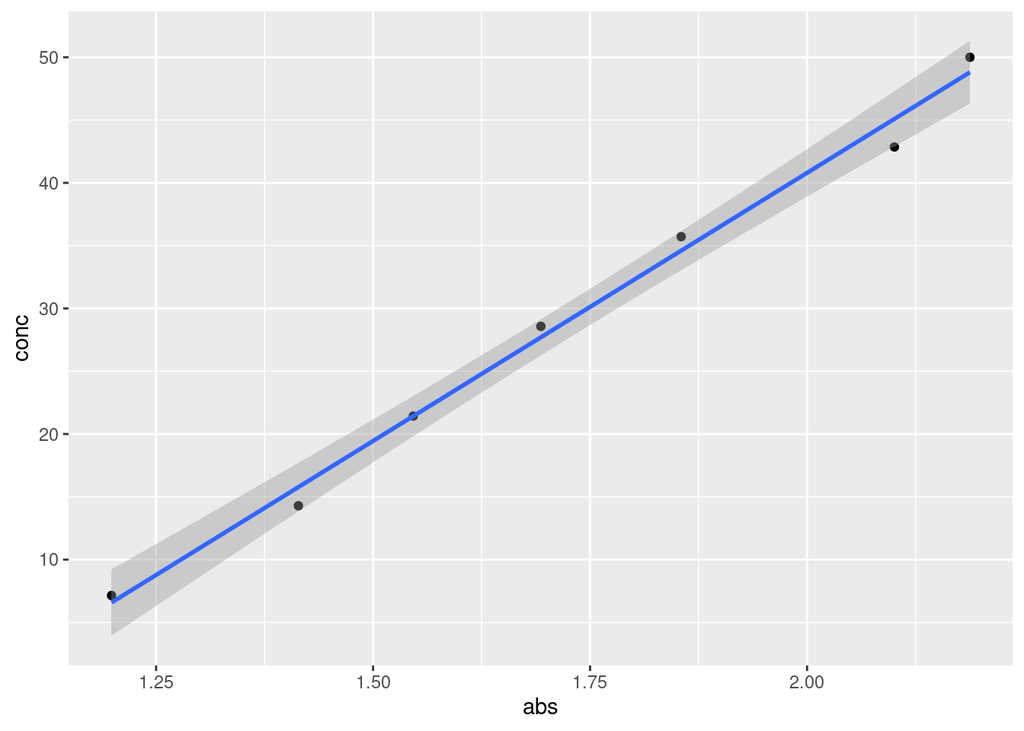

```r
# 2, 3, 4 sind die Standards
HSA.A <- mutate(HSA.A, Std=((HSA.A$s2 + HSA.A$s3 + HSA.A$s4) / 3))

# Die Spalten 5&6, 7&8 sowie 9&10 führen neben einander die
# Probenabsorption
Proben.1.A <- c((HSA.A$s5 + HSA.A$s6)/2 , (HSA.A$s7[1:4]+HSA.A$s8[1:4])/2)
Proben.2.A <- c((HSA.A$s9 + HSA.A$s10)/2 , (HSA.A$s7[5:8]+HSA.A$s8[5:8])/2)

# Es ist bekannt, dass Proben.1 1:5000 verdünnt wurde:
Proben.1.A <- Proben.1.A * 5000

# Proben.2 wurde 1:1000 Verdünnt
Proben.2.A <- Proben.2.A * 1000

# Plot der Regression
plot_regression(abs = HSA.A$Std[2:8], conc = subs[2:8])
```

```r
# Definition einer einfachen Funktion
cHSA.A <- function (abs.P) {
    conc_eval( abs.P, abs_std = HSA.A$Std, conc_std = subs)
}

# Testen der Funktion
conc.1.A <- cHSA(abs.P = Proben.1.A)
```

```
##
## Call:
## stats::lm(formula = conc_std ~ abs_std)
##
## Residuals:
##     Min      1Q  Median      3Q     Max
## -3.8271 -0.8993 -0.0267  0.8181  3.2498
##
## Coefficients:
##             Estimate Std. Error t value Pr(>|t|)
## (Intercept)  4.74406    1.30180   3.644   0.0108 *
## abs_std      0.95322    0.04779  19.945 1.03e-06 ***
## ---
## Signif. codes:  0 '***' 0.001 '**' 0.01 '*' 0.05 '.' 0.1 ' ' 1
##
## Residual standard error: 2.304 on 6 degrees of freedom
## Multiple R-squared:  0.9851, Adjusted R-squared:  0.9827
## F-statistic: 397.8 on 1 and 6 DF,  p-value: 1.031e-06
```

```r
# Berechnung der Konzentrationen
conc.2.A <- cHSA(Proben.2.A)
```

```
##
## Call:
## stats::lm(formula = conc_std ~ abs_std)
##
## Residuals:
##     Min      1Q  Median      3Q     Max
## -3.8271 -0.8993 -0.0267  0.8181  3.2498
##
## Coefficients:
##             Estimate Std. Error t value Pr(>|t|)
## (Intercept)  4.74406    1.30180   3.644   0.0108 *
## abs_std      0.95322    0.04779  19.945 1.03e-06 ***
## ---
## Signif. codes:  0 '***' 0.001 '**' 0.01 '*' 0.05 '.' 0.1 ' ' 1
##
## Residual standard error: 2.304 on 6 degrees of freedom
## Multiple R-squared:  0.9851, Adjusted R-squared:  0.9827
## F-statistic: 397.8 on 1 and 6 DF,  p-value: 1.031e-06
```

```r
# Untersuchung der Patienten-Proben
Patient.1.A <- (sum(HSA.A[1:2, 11], HSA.A[1:2, 12]) / 4) * 20000
Patient.2.A <- (sum(HSA.A[4:5, 11], HSA.A[4:5, 12]) /4) * 100000

# Berechnung der Patienten-Proben-Konzentration
cHSA(Patient.1.A)
```

```
##
## Call:
## stats::lm(formula = conc_std ~ abs_std)
##
## Residuals:
##     Min      1Q  Median      3Q     Max
## -3.8271 -0.8993 -0.0267  0.8181  3.2498
##
## Coefficients:
##             Estimate Std. Error t value Pr(>|t|)
## (Intercept)  4.74406    1.30180   3.644   0.0108 *
## abs_std      0.95322    0.04779  19.945 1.03e-06 ***
## ---
## Signif. codes:  0 '***' 0.001 '**' 0.01 '*' 0.05 '.' 0.1 ' ' 1
##
## Residual standard error: 2.304 on 6 degrees of freedom
## Multiple R-squared:  0.9851, Adjusted R-squared:  0.9827
## F-statistic: 397.8 on 1 and 6 DF,  p-value: 1.031e-06
```

```
## abs_std
##   11105
```

```r
cHSA(Patient.2.A)
```

```
##
## Call:
## stats::lm(formula = conc_std ~ abs_std)
##
## Residuals:
##     Min      1Q  Median      3Q     Max
## -3.8271 -0.8993 -0.0267  0.8181  3.2498
##
## Coefficients:
##             Estimate Std. Error t value Pr(>|t|)
## (Intercept)  4.74406    1.30180   3.644   0.0108 *
## abs_std      0.95322    0.04779  19.945 1.03e-06 ***
## ---
## Signif. codes:  0 '***' 0.001 '**' 0.01 '*' 0.05 '.' 0.1 ' ' 1
##
## Residual standard error: 2.304 on 6 degrees of freedom
## Multiple R-squared:  0.9851, Adjusted R-squared:  0.9827
## F-statistic: 397.8 on 1 and 6 DF,  p-value: 1.031e-06
```

```
##  abs_std
## 73474.23
```

```r
####### Vergleich der Ergebnisse ##################################

# als erstes sollten wir überprüfen, dass es sich tatsächlich um
# zwei verschiedene Datensätze handelt
HSA == HSA.A
```

```
##      clara    s1    s2    s3    s4    s5    s6    s7    s8    s9
## [1,]  TRUE FALSE FALSE FALSE FALSE FALSE FALSE FALSE FALSE FALSE
## [2,]  TRUE FALSE FALSE FALSE FALSE FALSE FALSE FALSE FALSE FALSE
## [3,]  TRUE FALSE FALSE FALSE FALSE FALSE FALSE FALSE FALSE FALSE
## [4,]  TRUE FALSE FALSE FALSE FALSE FALSE FALSE FALSE FALSE FALSE
## [5,]  TRUE FALSE FALSE FALSE FALSE FALSE FALSE FALSE FALSE FALSE
## [6,]  TRUE FALSE FALSE FALSE FALSE FALSE FALSE FALSE FALSE FALSE
## [7,]  TRUE FALSE FALSE FALSE FALSE FALSE FALSE FALSE FALSE FALSE
## [8,]  TRUE FALSE FALSE FALSE FALSE FALSE FALSE FALSE FALSE FALSE
##        s10   s11   s12   Std
## [1,] FALSE FALSE FALSE FALSE
## [2,] FALSE FALSE FALSE FALSE
## [3,] FALSE FALSE FALSE FALSE
## [4,] FALSE FALSE FALSE FALSE
## [5,] FALSE FALSE FALSE FALSE
## [6,] FALSE FALSE FALSE FALSE
## [7,] FALSE FALSE FALSE FALSE
## [8,] FALSE FALSE FALSE FALSE
```

[figure not shown]

```r
boxplot(Patient.1.A ,Patient.1, Patient.2.A, Patient.2)
```

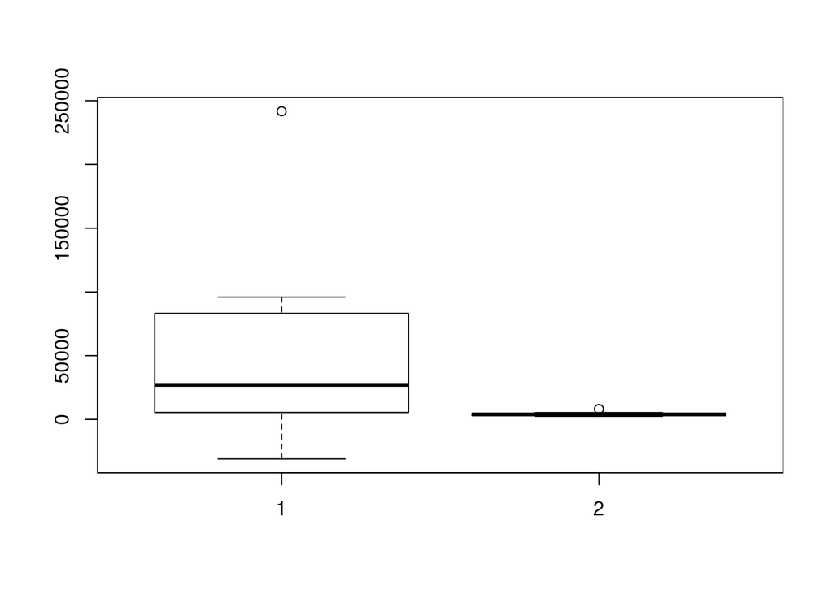

```r
boxplot(conc.1, conc.1.A)
```

[figure not shown]

```r
boxplot(conc.2, conc.2.A)
```

[figure not shown]

```r
boxplot(conc.1.A, conc.2.A)
```

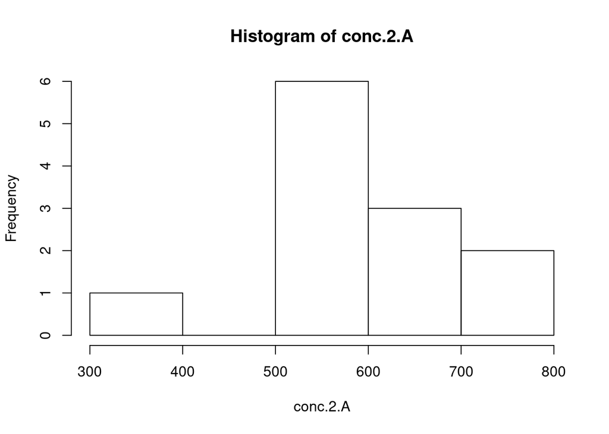

```r
hist(conc.2.A)
```

```r
library(outliers)
outlier(conc.2.A)
```

```
## [1] 319.7835
```

## 5.3 Berücksichtigung des Verdünnungsfaktor

Die Verdünnungsfaktoren sind Bekannt, sie müssen lediglich mit-einberechnet werden. Man könnte die Funktion zusätzlich erweitern:

```r
HSA.conc.eval <- function(HSA,
         mes,
         FV = 1) {
  stdr <- HSA[3:5]  %>%
    rowMeans()
  conc <- c(0, 5, 10, 15, 20, 30, 40, 50)
  eval <- conc_eval(abs_P = mes,
            abs_std = stdr,
            conc_std = conc)
  return(eval * FV)
}

# Testen mit dem zweiten Datensatz
HSA.conc.eval(HSA2, HSA2[3:5])
```

```
##
## Call:
## stats::lm(formula = conc_std ~ abs_std)
##
## Residuals:
##    Min     1Q Median     3Q    Max
## -4.455 -3.896 -0.661  1.751  6.856
##
## Coefficients:
##             Estimate Std. Error t value Pr(>|t|)
## (Intercept)  -39.560      6.824  -5.797  0.00115 **
## abs_std       37.805      4.106   9.207 9.26e-05 ***
## ---
## Signif. codes:  0 '***' 0.001 '**' 0.01 '*' 0.05 '.' 0.1 ' ' 1
##
## Residual standard error: 4.853 on 6 degrees of freedom
## Multiple R-squared:  0.9339, Adjusted R-squared:  0.9229
## F-statistic: 84.76 on 1 and 6 DF,  p-value: 9.261e-05
```

```
##         s2       s3        s4
## 1 -6.63252 -7.69105 -5.384965
## 2  5.99424  5.99424  5.275952
## 3 13.59298 15.59663 12.496644
## 4 18.99905 18.58320 19.112461
## 5 25.38804 23.68683 24.291701
## 6 31.09654 31.13435 29.470941
## 7 38.88430 41.15258 39.526983
## 8 44.63061 43.38306 41.417216
```

Da nach dem Auftragsschema die Verdünnungsfaktoren auch in den Spalten variieren können müssen wir uns diese noch ein mal genauer ansehen.

```r
dat.1 <- tibble(
 "FV1000" = c(rowMeans(HSA2[,6:7]),
              rowMeans(HSA2[1:4, 8:9])
              ),
 "FV5000" = c(rowMeans(HSA2[5:8, 8:9]),
              rowMeans(HSA2[,10:11])
              )
)
conc.1 <- tibble(
  "aus FV1000" = HSA.conc.eval(HSA2, dat.1$"FV1000", 1000),
  "aus FV5000" =  HSA.conc.eval(HSA2, dat.1$FV5000, 5000)
)
```

```
##
## Call:
## stats::lm(formula = conc_std ~ abs_std)
##
## Residuals:
##    Min     1Q Median     3Q    Max
## -4.455 -3.896 -0.661  1.751  6.856
##
## Coefficients:
##             Estimate Std. Error t value Pr(>|t|)
## (Intercept)  -39.560      6.824  -5.797  0.00115 **
## abs_std       37.805      4.106   9.207 9.26e-05 ***
## ---
## Signif. codes:  0 '***' 0.001 '**' 0.01 '*' 0.05 '.' 0.1 ' ' 1
##
## Residual standard error: 4.853 on 6 degrees of freedom
## Multiple R-squared:  0.9339, Adjusted R-squared:  0.9229
## F-statistic: 84.76 on 1 and 6 DF,  p-value: 9.261e-05
##
##
## Call:
## stats::lm(formula = conc_std ~ abs_std)
##
## Residuals:
##    Min     1Q Median     3Q    Max
## -4.455 -3.896 -0.661  1.751  6.856
##
## Coefficients:
##             Estimate Std. Error t value Pr(>|t|)
## (Intercept)  -39.560      6.824  -5.797  0.00115 **
## abs_std       37.805      4.106   9.207 9.26e-05 ***
## ---
## Signif. codes:  0 '***' 0.001 '**' 0.01 '*' 0.05 '.' 0.1 ' ' 1
##
## Residual standard error: 4.853 on 6 degrees of freedom
## Multiple R-squared:  0.9339, Adjusted R-squared:  0.9229
## F-statistic: 84.76 on 1 and 6 DF,  p-value: 9.261e-05
```

```r
conc.1
```

```
## # A tibble: 12 x 2
##    `aus FV1000` `aus FV5000`
##           <dbl>        <dbl>
##  1      -10640.      -97431.
##  2      -12719.      -65202.
##  3       -1945.      -79662.
##  4       24802.      -59909.
##  5       -5839.      -95918.
##  6      -15687.     -135330.
##  7      -16235.      -91854.
##  8       -4875.      -52727.
##  9       -2531.      -89870.
## 10      -20337.      -93650.
## 11        2743.      -81175.
## 12      -19467.      -60855.
```

# 6 Ein Progesteron-Assay

```r
# Progesteron-Assay
# Laden der Standardreih# Die Werte, welche als Grundlage für die Standardreihe verwendet werden wurden
# hierbei noch verändert, es wird angenommen, dass die Spalte MW Werte auslässt,
# welche den Mittelwert zu stark verfälschene
library(readxl)
# Die Excel-Tabelle findet ihr im GitHub-Repository
# https://github.com/BiotechBeuth/Str1
STR1 <- read_excel("Pfad/zur/Datei/STR1.xlsx")
str(STR1)

# Laden von Biotech
library(devtools)
load_all("../../Biotech")

#
library(tidyverse)

# Errechnen der Mittelwerte
STR1 <- mutate(STR1, Std = (STR1$E1 + STR1$E2 + STR1$E3)/3)

# Vergleich der Mittelwerte aus den Standards und den von der Gruppe errechneten Werten:
tibble(
        STR1$MW == STR1$Std,
        STR1$MW,
        STR1$Std
)
# Die Werte, welche als Grundlage für die Standardreihe verwendet werden wurden
# hierbei noch verändert, es wird angenommen, dass die Spalte MW Werte auslässt,
# welche den Mittelwert zu stark verfälschen
dose_response_plot(STR1$conc,STR1$Std)
dose_response_plot(STR1$conc,STR1$MW)
# Das nicht-lineare Modell:
library(dr4pl)
fit <-  dr4pl(STR1$conc[1:8]~STR1$MW[1:8])
conc.eval.DR <- function (abs.P) {
   fit$parameters[1] + ((fit$parameters[4] - fit$parameters[1])/(1 + (abs.P/fit$parameters[2])^fit$parameters[3]))
}
conc.eval.DR(STR1$Std)

# Export der generierten Daten
write.csv(STR1, "./STR1.csv")
```

# 7 Untersuchung der Messdaten eines Aufschlusses von Hefe in einer Rührwerkskugelmühle

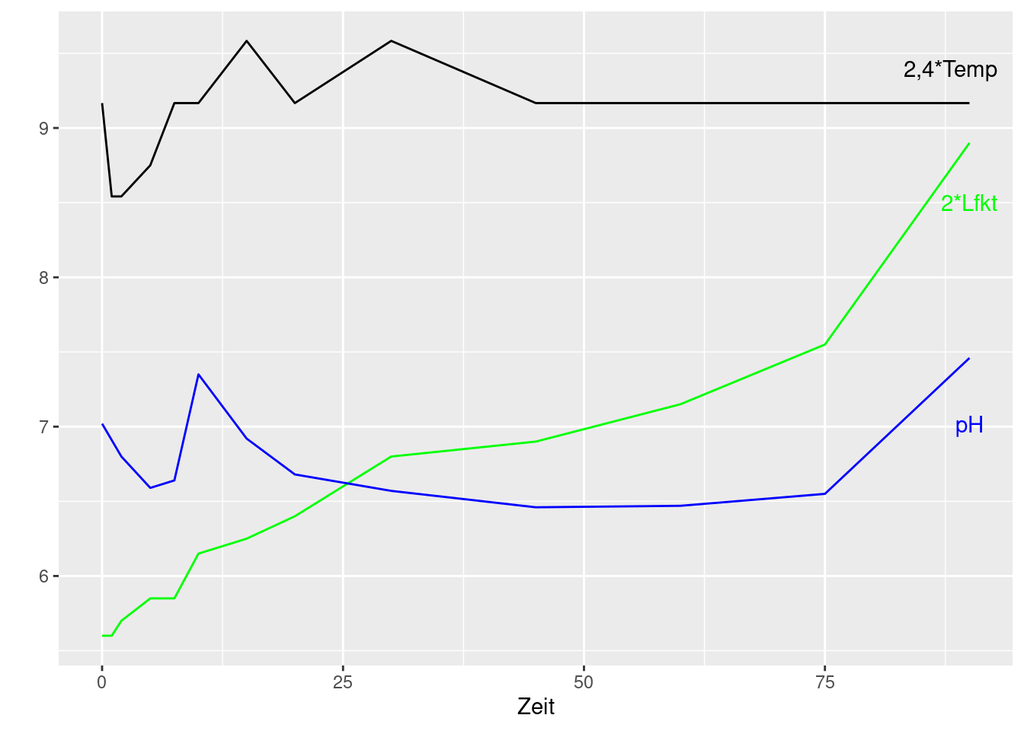

```r
# Laden der benötigten Pakete
library(pander)
library(ggplot2)

# Übertragung der Rohdaten
zeit <- c(0,1,2,5,7.5,10,15,20,30,45,60,75,90)

# Bei i handelt es sich um das theoretische Volumen der Aufschlussflüssigkeit
# dieses steigt oder sinkt unter Zugabe von Lauge oder Probennahme
i <- c( 4000+0,
        3985+0,
        3970+0,
        3955+5,
        3940+5+42,
        3925+5+42+0,
        3910+5+42+0+0,
        3895+5+42+0+0+23,
        3880+5+42+0+0+23+30,
        3865+5+42+0+0+23+30+36,
        3850+5+42+0+0+23+30+36+46,
        3835+5+42+0+0+23+30+36+46+26,
        3820+5+42+0+0+23+30+36+46+26)

# Bei N handelt es sich um die theoretische Passagenzahl
N <- ((10000/i)*(zeit/60))

# Rohdaten des Bradfordassay
Std <-  seq(0,100,20)
Abs <- c(.374,
         .5,
         .617,
         .78,
         .874,
         .985)

# Probennahme-Zeitpunkte
zeit <- c(0,1,2,5,7.5,10,15,20,30,45,60,75,90)

# Verdünnungsfaktoren der Einzelmessungen
FV <- c(20,20,20,20,20,20,20,20,20,50,50,50,50)

# Absorptionsmessungen des Bradford-Assay
Absorbtion <- c(.346 , .384 , .501 , .603 , .607 , .725 , .7153 , .801 , 1.018 , .689 , .721 , .753 , .740)

# Fumaraseaktivität
Aktivit <- c(0 ,.26 , 1.07 , 1.619 , 3 , 2.3 , 3.26 , 7.22 , 15.75 , 11.3 , 10.52 , 9.98 , 12.36)
i <- 4000

# Leitfähigkeit der Aufschlussflüssigkeit
Leitf <- c(11.2,11.2,11.4,11.7,11.7,12.3,12.5,12.8,13.6,13.8,14.3,15.1,17.8)

# Temperatur der Aufschlussflüssigkeit
Temp <- c(22,20.5,20.5,21,22,22,23,22,23,22,22,22,22)

# pH der Aufschlussflüssigkeit
ph <- c(7.02,6.91,6.8,6.59,6.64,7.35,6.92,6.68,6.57,6.46,6.47,6.55,7.46)

# Zugabevolumen an Lauge (Kalilauge)
KOH <- c(0,0,0,5,42,0,0,23,30,36,46,0,0)

# Zugabe an Lauge (Natronlauge)
NaOH <- c(0,0,0,0,0,0,0,0,0,0,0,26,0)


ggplot(mapping = aes(y=Leitf/2, x=zeit))+
  geom_line(color="green")+
  geom_line(mapping = aes(zeit , ph) , color = "blue")+
  geom_line(mapping = aes(zeit,Temp/2.4))+
  ylab("")+
  xlab("Zeit")+
  annotate(geom = "text", y = 8.5, x = 90, label = expression("2*Lfkt"), color = "green" )+
  annotate(geom = "text", y = 7, x = 90, label = expression("pH"), color = "blue" )+
  annotate(geom = "text", y = 9.4, x = 88, label = "2,4*Temp")
```

```r
# Plotten der Regressionsgerade
(sum <- (summary(lm(Abs~Std))))
```

```
##
## Call:
## lm(formula = Abs ~ Std)
##
## Residuals:
##          1          2          3          4          5          6
## -0.0043333 -0.0023333 -0.0093333  0.0296667 -0.0003333 -0.0133333
##
## Coefficients:
##              Estimate Std. Error t value Pr(>|t|)
## (Intercept) 0.3783333  0.0123744   30.57 6.82e-06 ***
## Std         0.0062000  0.0002044   30.34 7.03e-06 ***
## ---
## Signif. codes:  0 '***' 0.001 '**' 0.01 '*' 0.05 '.' 0.1 ' ' 1
##
## Residual standard error: 0.0171 on 4 degrees of freedom
## Multiple R-squared:  0.9957, Adjusted R-squared:  0.9946
## F-statistic: 920.5 on 1 and 4 DF,  p-value: 7.031e-06
```

[figure not shown]

```r
ggplot()+
  geom_point(mapping = aes(Std,Abs))+
  geom_smooth(mapping = aes(Std,Abs), method = "lm")+
  xlab("Absorption")+
  ylab("Konzentration")+
# Einplotten einer Verlängerungsgeraden
  geom_abline(slope = 0.0062000 , intercept = 0.3783333 )
```

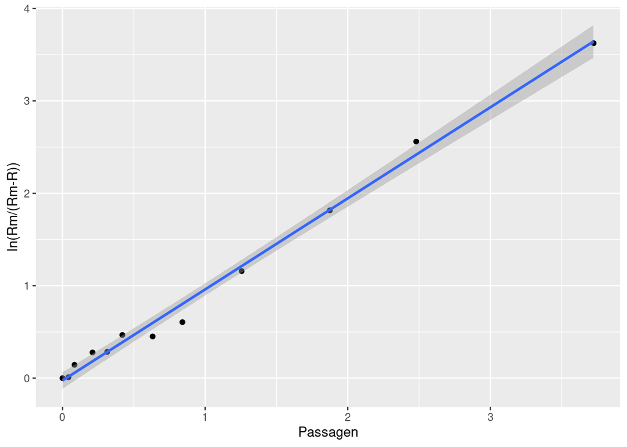

```r
# Aufschlusskonstante gegen Passsagen Plotten
Konzentration <- c( 0, 0.2880  ,4.0320 , 7.2960 , 7.4240 , 11.2000 , 10.8896 , 13.6320 , 20.5760 ,25.12 , 27.68 , 30.24 , 29.20 )
y <- (log(30/(30- Konzentration )))
ggplot()+
  geom_point(mapping = aes( N , y ))+
  geom_smooth(mapping = aes( N , y ),method = "lm")+
  xlab("Passagen")+
  ylab("ln(Rm/(Rm-R))")
```

```r
# Summary des Fit
summary(lm(N~y))
```

```
##
## Call:
## lm(formula = N ~ y)
##
## Residuals:
##       Min        1Q    Median        3Q       Max
## -0.131102 -0.086560 -0.003212  0.044357  0.197544
##
## Coefficients:
##             Estimate Std. Error t value Pr(>|t|)
## (Intercept)  0.03283    0.04001   0.821    0.431
## y            1.00735    0.02755  36.558 5.58e-12 ***
## ---
## Signif. codes:  0 '***' 0.001 '**' 0.01 '*' 0.05 '.' 0.1 ' ' 1
##
## Residual standard error: 0.1048 on 10 degrees of freedom
##   (1 observation deleted due to missingness)
## Multiple R-squared:  0.9926, Adjusted R-squared:  0.9918
## F-statistic:  1337 on 1 and 10 DF,  p-value: 5.577e-12
```

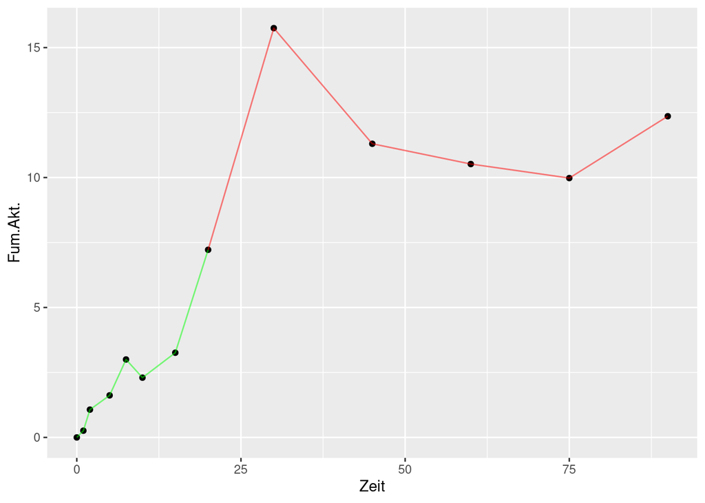

```r
# Fumarase-Aktivität gegen die Zeit
ggplot(mapping = aes(zeit,Aktivit))+
  geom_point()+
  geom_line(mapping = aes(zeit[1:8],Aktivit[1:8]), color="green",alpha=.5)+
  geom_line(mapping = aes(zeit[8:13],Aktivit[8:13]), color="red",alpha=.5)+
  ylab("Fum.Akt.")+
  xlab("Zeit")
```

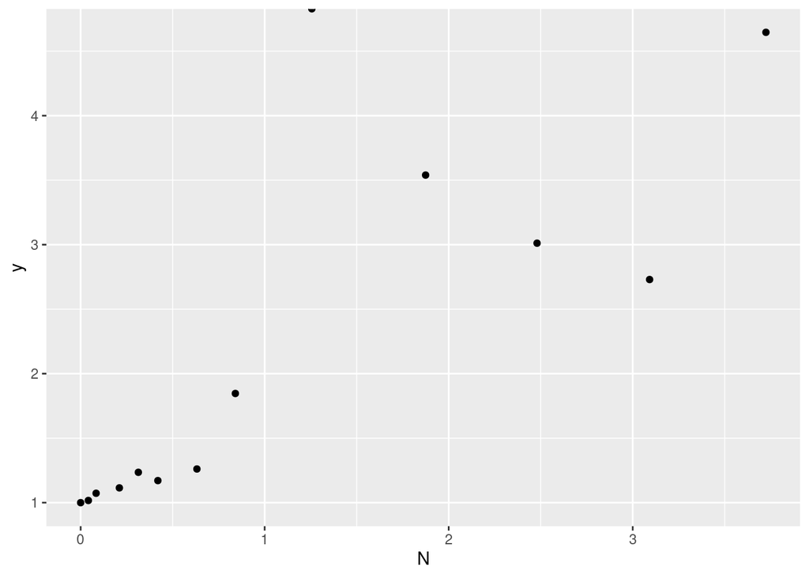

```r
# Untersuchung der Aktivitätsmessung
Aktivit <- c(0 ,.26 , 1.07 , 1.619 , 3 , 2.3 , 3.26 , 7.22 , 15.75 , 11.3 , 10.52 , 9.98 , 12.36)
y <- max(Aktivit) / ( max(Aktivit)-Aktivit )

qplot(N, y)
```